# Modelos ARIMAX

- Mostrar todo el código
- Ocultar todo el código
- Ver el código fuente

Natalidad mensual y variables demográficas

Autor/a

Rodrigo B

# Contexto del problema

## Demografía y natalidad

La natalidad es uno de los tres componentes de la dinámica demográfica (junto con la mortalidad y la migración). Anticipar el número de nacimientos es importante para diversos aspectos.

Los expertos han estipulado que la natalidad presenta tres características típicas:

- Tendencia de largo plazo (creciente o decreciente por la transición demográfica).
- Estacionalidad anual (más nacimientos en ciertos meses del año).
- Sensibilidad al contexto socioeconómico: el desempleo, crisis económicas y la participación laboral femenina influyen, a veces su efecto no es inmediato, también hay eventos como la pandemia de COVID-19 generaron cambios abruptos.

## Pregunta de investigación

> ¿Es posible modelar y pronosticar el número mensual de nacimientos incorporando información socioeconómica (variables exógenas o covariables)? ¿Cómo se compara este modelo con respecto a uno que sólo usa la historia de la serie (**ARIMA**) o uno que solo considera la relación con variables exógenas (**Regresión lineal**)?

## ¿Qué es un ARIMAX?

Un ARIMAX es una regresión con errores ARIMA, que combina la relación entre una variable de respuesta y sus covariables pero mantiene la dependencia temporal de la variable de respuesta. Su forma general es:

$$y_t = \beta_0 + \sum_{k=1}^{K}\beta_k x_{k,t} + \eta_t, \qquad$$

Donde $\eta_t$ es un modelo $ARIMA(p,d,q)(P,D,Q)_s$ que captura la dependencia temporal de los errores.
$$\Phi(B^s)\,\phi(B)\,(1-B)^d(1-B^s)^D\,\eta_t = \Theta(B^s)\,\theta(B)\,\varepsilon_t$$

Hay que tener cuidado con la innterpretación de la regresión en caso de realizar diferenciaciones.

## Diccionario de variables

| Variable | Descripción | Unidad |
| --- | --- | --- |
| `fecha` | Primer día del mes | fecha |
| `nacimientos` | Nacimientos registrados en el mes (**variable respuesta**) | miles |
| `desempleo` | Tasa de desocupación | % |
| `pib_var` | Variación anualizada de la actividad económica | % |
| `part_fem` | Tasa de participación laboral femenina | % |
| `mort_inf` | Tasa de mortalidad infantil | cada mil nacidos vivos |
| `pandemia` | Indicador (0/1) del efecto rezagado de la pandemia (2021) | dummy |

# Análisis exploratorio (EDA)

Un error común es asumir que la base de datos está limpia y lista para modelar. Antes de cualquier análisis, conviene inspeccionar la integridad de los datos, la presencia de valores faltantes, la coherencia de los registros y la existencia de valores atípicos.

**Código**

```r
glimpse(datos_crudos)
```

```
Rows: 288
Columns: 7
$ fecha       <date> 2000-01-01, 2000-02-01, 2000-03-01, 2000-04-01, 2000-05-0…
$ nacimientos <dbl> 219.8, 225.7, 225.4, 219.4, 216.0, 213.0, 212.9, 214.1, 21…
$ desempleo   <dbl> 4.33, 4.47, 4.44, 4.39, 4.20, 4.19, 4.09, 4.12, 3.98, 3.84…
$ pib_var     <dbl> 1.95, 1.58, 0.79, 2.14, 0.94, 2.98, 2.66, 2.23, 3.05, 2.54…
$ part_fem    <dbl> 38.01, 38.00, 38.04, 38.05, 38.13, 38.21, 38.22, 38.24, 38…
$ mort_inf    <dbl> 21.82, 21.56, 21.69, 21.64, 21.05, 21.15, 20.88, 21.08, 20…
$ pandemia    <int> 0, 0, 0, 0, 0, 0, 0, 0, 0, 0, 0, 0, 0, 0, 0, 0, 0, 0, 0, 0…
```

**Código**

```r
summary(datos_crudos)
```

```
     fecha             nacimientos     desempleo        pib_var
 Min.   :2000-01-01   Min.   :-150   Min.   : 3.78   Min.   :-6.62
 1st Qu.:2005-12-24   1st Qu.: 152   1st Qu.: 4.56   1st Qu.: 1.66
 Median :2011-11-16   Median : 171   Median : 4.92   Median : 2.28
 Mean   :2011-11-30   Mean   : 176   Mean   : 5.13   Mean   : 2.05
 3rd Qu.:2017-11-08   3rd Qu.: 193   3rd Qu.: 5.21   3rd Qu.: 2.87
 Max.   :2023-12-01   Max.   :1780   Max.   :45.00   Max.   : 4.99
                      NAs    :4      NAs    :10      NAs    :9
    part_fem        mort_inf        pandemia
 Min.   : 38.0   Min.   : 3.74   Min.   :0.0000
 1st Qu.: 41.0   1st Qu.: 6.03   1st Qu.:0.0000
 Median : 44.5   Median : 9.34   Median :0.0000
 Mean   : 45.0   Mean   :10.46   Mean   :0.0417
 3rd Qu.: 48.1   3rd Qu.:14.06   3rd Qu.:0.0000
 Max.   :150.0   Max.   :21.82   Max.   :1.0000
 NAs    :3
```

¿Estas tablas son suficientes para realizar un diagnóstico de calidad de datos? ¿Qué otras herramientas podrían ayudar a detectar problemas?

Vamos a verificar la integridad temporal (duplicados y meses faltantes)

**Código**

```r
# Duplicados
duplicados <- datos_crudos |> count(fecha) |> filter(n > 1)
duplicados
```

```
# A tibble: 1 × 2
  fecha          n
  <date>     <int>
1 2008-04-01     2
```

**Código**

```r
# Meses faltantes en la secuencia esperada
secuencia <- seq(min(datos_crudos$fecha), max(datos_crudos$fecha), by = "month")
meses_faltantes <- setdiff(secuencia, datos_crudos$fecha) |> as.Date()
meses_faltantes
```

```
[1] "2020-10-01"
```

En nuestro contexto, basta con eliminar los registros duplicados y el mes ausente se agrega con valores `NA` para ser imputado después.

**Código**

```r
datos <- datos_crudos |>
  distinct() |>
  complete(fecha = secuencia) |>
  arrange(fecha) |>
  # el indicador de pandemia es determinístico: se reconstruye desde la fecha
  mutate(pandemia = as.integer(fecha >= as.Date("2021-01-01") &
                               fecha <= as.Date("2021-12-01")))

stopifnot(nrow(datos) == 288, !anyDuplicated(datos$fecha))
```

Para analizar los valores faltantes (NA) de una base, se puede usar estadísticas descriptivas sin embargo será de mayor utilidad una visualización que muestre la distribución de los NA por variable y por observación. La función `vis_miss()` de `naniar` es muy útil para este propósito.

**Código**

```r
miss_var_summary(datos) |> kable(digits = 2, caption = "Resumen de NA por variable")
```

Resumen de NA por variable

| variable | n_miss | pct_miss |
| --- | --- | --- |
| desempleo | 11 | 3.82 |
| pib_var | 9 | 3.12 |
| nacimientos | 5 | 1.74 |
| part_fem | 4 | 1.39 |
| mort_inf | 1 | 0.347 |
| fecha | 0 | 0 |
| pandemia | 0 | 0 |

**Código**

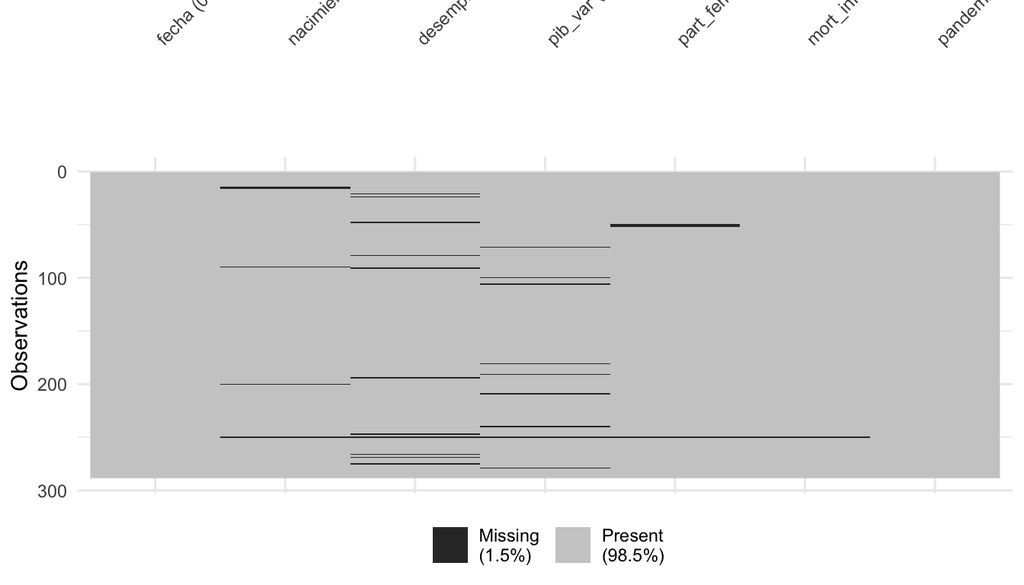

```r
vis_miss(datos)
```

Antes de imputar, conviene determinar si la ausencia es aleatoria o parece existir un patrón.

**Código**

```r
# Longitud de las rachas de NA en la variable respuesta y exógenas
rachas <- function(x) {
  r <- rle(is.na(x)); if (!any(r$values)) return(0L); max(r$lengths[r$values])
}
datos |> summarise(across(c(nacimientos, desempleo, pib_var, part_fem, mort_inf), rachas)) |>
  kable(caption = "Racha máxima de NA consecutivos")
```

Racha máxima de NA consecutivos

| nacimientos | desempleo | pib_var | part_fem | mort_inf |
| --- | --- | --- | --- | --- |
| 2 | 1 | 1 | 3 | 1 |

## Coherencia de los registros

- Nacimientos deben ser **estrictamente positivos**.
- Tasas porcentuales (`desempleo`, `part_fem`) deben estar en rangos plausibles: desempleo en $[0, 25]$ %; participación en $[0, 100]$ %.

**Código**

```r
incoherencias <- datos |>
  summarise(
    nacimientos_no_positivos  = sum(nacimientos <= 0, na.rm = TRUE),
    desempleo_fuera_de_rango  = sum(desempleo < 0 | desempleo > 25, na.rm = TRUE),
    part_fem_fuera_de_rango   = sum(part_fem < 0 | part_fem > 100, na.rm = TRUE),
    mort_inf_fuera_de_rango   = sum(mort_inf <= 0 | mort_inf > 1000, na.rm = TRUE)
  )
kable(incoherencias, caption = "Violaciones de reglas de coherencia")
```

Violaciones de reglas de coherencia

| nacimientos_no_positivos | desempleo_fuera_de_rango | part_fem_fuera_de_rango | mort_inf_fuera_de_rango |
| --- | --- | --- | --- |
| 1 | 1 | 1 | 0 |

Los valores que violan las reglas se convierten en `NA` (no se “corrigen” a mano, porque no sabemos cuál era el valor verdadero)

**Código**

```r
datos <- datos |>
  mutate(
    nacimientos = if_else(nacimientos <= 0, NA_real_, nacimientos),
    desempleo   = if_else(desempleo < 0 | desempleo > 25, NA_real_, desempleo),
    part_fem    = if_else(part_fem < 0 | part_fem > 100, NA_real_, part_fem),
    mort_inf    = if_else(mort_inf <= 0 | mort_inf > 1000, NA_real_, mort_inf)
  )
```

## Detección de valores atípicos

Un atípico en una serie con tendencia y estacionalidad no se detecta con un simple rango intercuartílico sobre los datos crudos (la tendencia lo enmascara).

**Código**

```r
# Serie provisional (interpolación lineal) sólo para poder aplicar STL
prov <- na_interpolation(ts(datos$nacimientos, start = c(2000, 1), frequency = 12))
stl_prov <- stl(prov, s.window = "periodic", robust = TRUE)
resid_stl <- stl_prov$time.series[, "remainder"]

umbral <- 4 * mad(resid_stl)
atipicos <- which(abs(resid_stl - median(resid_stl)) > umbral)

datos[atipicos, c("fecha", "nacimientos")]
```

```
# A tibble: 7 × 2
  fecha      nacimientos
  <date>           <dbl>
1 2014-02-01       1780
2 2020-11-01        143
3 2020-12-01        147.
4 2021-09-01        107
5 2021-10-01        110.
6 2021-11-01        113.
7 2021-12-01        120.
```

**Código**

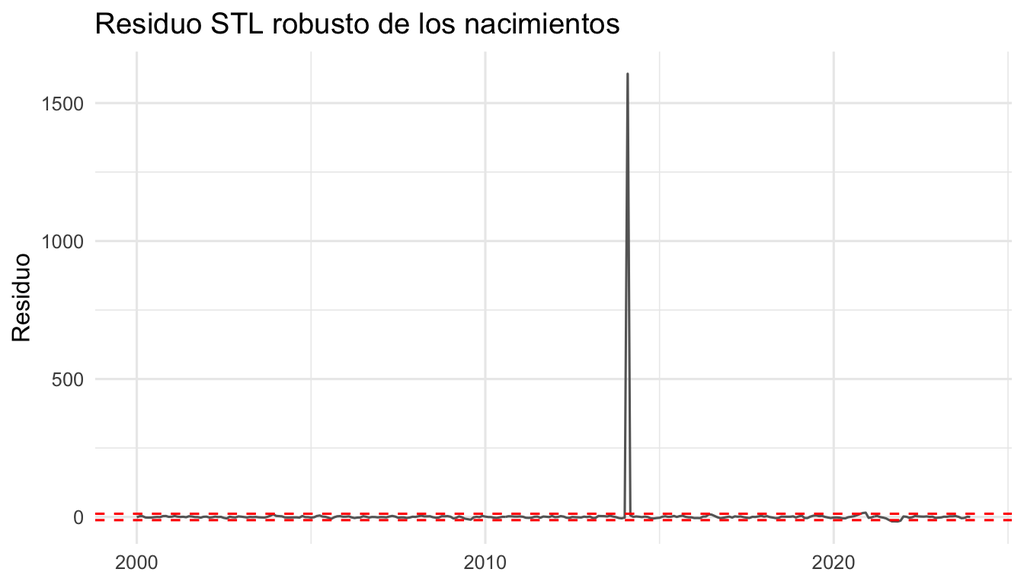

```r
tibble(fecha = datos$fecha, residuo = as.numeric(resid_stl)) |>
  ggplot(aes(fecha, residuo)) +
  geom_line(color = "grey40") +
  geom_hline(yintercept = c(-umbral, umbral) + median(resid_stl),
             linetype = "dashed", color = "red") +
  labs(title = "Residuo STL robusto de los nacimientos", x = NULL, y = "Residuo")
```

**Código**

```r
datos$nacimientos[atipicos] <- NA
```